# Human Activity Recognition

Keith Erskine

1/19/2018

## Summary

Using a random forest method, a model with 99% was produced. However to do it, parallel computing was required.

The model is based on sensing data from measurement systems (acceleration, gyroscope, magnetometer) on test subjects doing a curl (weight lifting exercise). During testing, each exercise was evaluated for correct form, or not, and given a designation; “A” for proper form, “B, C, D, E” for various improper forms. The goal was to develop model that would predict if someone is doing the exercise correctly, and if not, which of the bad forms was being performed.

### Acknowledgements

Special thanks goes to the Pontifical [Catholic University of Rio de Janeiro, Departamento de Informática](http://groupware.les.inf.puc-rio.br/har) for the data set and research used in this analysis.

## Data Acquisition and Cleaning

First, we need to download the data sets create some tibbles (I’m using tidyverse, so they’re tibbles and not dataframes).

```r
library(tidyverse)
library(caret)

train <- read_csv("traincsv")
test <- read_csv("testcsv")
```

You can see that there’s a lot of #DIV/0 values in the training data set that read_csv takes care of with “NA”s. The test training set didn’t have these problems which made me wonder what was different out it.

Using the view command, we can see that whole swaths of data are missing from the test data set. Since there’s no sense in trying to build a predictive model on data that’s ignored, we’ll clean up both training and test data sets to have the same variables.

```r
dim(test)
```

```
## [1]  20 160
```

```r
dtest <- test %>% select_if(~ !any(is.na(.))) # Get rid of NA variables
dtest <- dtest %>% select(-X1, -user_name, -raw_timestamp_part_1,
                          -raw_timestamp_part_2, -cvtd_timestamp, -new_window,
                          -num_window, -new_window, -problem_id) # Get rid of housekeeping variables
dim(dtest)
```

```
## [1] 20 52
```

Now with the test data set done, it’s easy to get the training data set in shape.

```r
goodcols <- names(dtest)
dtrain <- train %>% select(goodcols, classe)
dtrain <- dtrain[complete.cases(dtrain),] # One record had some missing values
dtrain$classe <- as.factor(dtrain$classe) # Convert classe from character to factor
dim(dtrain)
```

```
## [1] 19621    53
```

So the training data is a very large set of 19,621 observations while the test set is only 20 observations. **This will greatly reduce our out of sample error** because of the size difference (980x) between training and test data sets.

## Exploratory Analysis

Here’s a graph that tries to look at the relationship between the acceleration between the arm and the dumbbell:

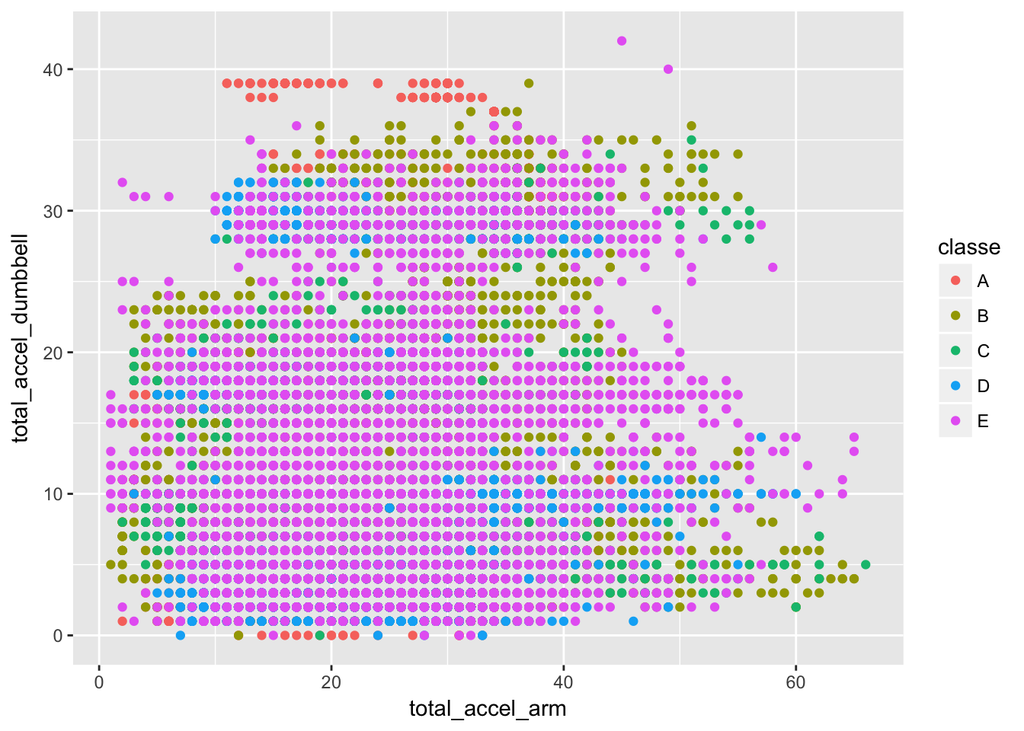

The colors represent the “classe” our the outcome variable. “A” means you’re doing a curl correctly, “B - E” are incorrect form. What’s interesting in this graph is that the proper form lies outside the blob of bad form.

However, we can’t look at 2704 (52x52) graphs to find the meaningful variables. Instead, we can try some predictive models and figure out one that is accurate enough for our purposes (e.g. passing the quiz).

## Predictive Model

Since the outcome is a factor (A, B, ..) and thus non-linear, the best type of predictive model is a decision tree where we factor the effect of predictive variables to predict an outcome. The first attempts at modeling were with classification and regression tree (rpart). The first model was took accelerometer from all axis as the predictors.

**Model 1: Accelerometers as Predictors**

```
## Bootstrapped (25 reps) Confusion Matrix
##
## (entries are percentual average cell counts across resamples)
##
##           Reference
## Prediction    A    B    C    D    E
##          A 21.4  8.6  9.6  4.3  4.7
##          B  0.9  4.7  1.3  0.4  3.3
##          C  0.1  1.1  1.7  0.2  0.7
##          D  5.9  5.0  4.8 11.4  4.2
##          E  0.1  0.1  0.0  0.1  5.4
##
##  Accuracy (average) : 0.4464
```

This model isn’t very accurate. Maybe if we use all the variables as predictors we would get more accurate model.

**Model 2: Use ALL the Variables**

```
## Bootstrapped (25 reps) Confusion Matrix
##
## (entries are percentual average cell counts across resamples)
##
##           Reference
## Prediction    A    B    C    D    E
##          A 24.7  7.8  7.3  6.7  2.6
##          B  0.9  7.1  0.7  3.2  2.8
##          C  2.3  3.6  8.9  4.8  3.7
##          D  0.4  0.6  0.5  1.4  0.7
##          E  0.2  0.2  0.0  0.2  8.6
##
##  Accuracy (average) : 0.5072
```

Better, but not by much. It’s time to call in the big guns – Random Forest! To do this, we’ll need to use parallel processing and run it on a number of CPU cores (this analysis was done on a 4-core processor). In addition, we’ll do cross validation of the predicting variables using k-fold (number of folds = 5).

You can find out more about parallel processing from [Len Greski’s excellent writeup](https://github.com/lgreski/datasciencectacontent/blob/master/markdown/pml-randomForestPerformance.md).

**Model 3: Random Forest**

```r
library(parallel)
library(doParallel)
cluster <- makeCluster(detectCores() - 1) # Leave a core for the OS
registerDoParallel(cluster)
fitcontrol <- trainControl(method = "cv", number = 5, allowParallel = TRUE)
ptm <- proc.time()
modrf <- dtrain %>% train(classe ~ ., method = "rf", trControl = fitcontrol, data = .)
confusionMatrix(modrf)
```

```
## Cross-Validated (5 fold) Confusion Matrix
##
## (entries are percentual average cell counts across resamples)
##
##           Reference
## Prediction    A    B    C    D    E
##          A 28.4  0.1  0.0  0.0  0.0
##          B  0.0 19.2  0.1  0.0  0.0
##          C  0.0  0.0 17.3  0.2  0.0
##          D  0.0  0.0  0.0 16.1  0.0
##          E  0.0  0.0  0.0  0.0 18.4
##
##  Accuracy (average) : 0.9945
```

```r
proc.time() - ptm
```

```
##    user  system elapsed
##  67.224   2.525 835.458
```

```r
stopCluster(cluster); registerDoSEQ() # Turn off parallel processing
```

## Results

Using a random forest method, I was able to produce a model with 99% accuracy! Applying this to the test data gives a 100% on the quiz that follows.

```r
testresults <- predict(modrf, newdata = dtest)
testresults
```

```
##  [1] B A B A A E D B A A B C B A E E A B B B
## Levels: A B C D E
```